# Phyloseq PreProcessing - abridged

Calla Bush St George

2024-05-03

# Setting the Environment

### Set my seed

```r
# Any number can be chose
set.seed(567890)
```

## Load Libraries

```r
pacman::p_load(tidyverse, devtools, patchwork, iNEXT, phyloseq,
               install = FALSE)
```

# Goals

1. Calculate the Hill Diversity of the samples.
2. Evaluate the rarefaction curves.
3. Evaluate the Diversity values.
4. Makes notes of specific samples and their seq depth.

# Diversity Calculations with iNEXT

## Load in Data

```r
load("data/02_PreProcessing/raw_preprocessed_physeq.RData")
raw_preprocessed_physeq
```

```
## phyloseq-class experiment-level object
## otu_table()   OTU Table:         [ 1736 taxa and 12 samples ]
## sample_data() Sample Data:       [ 12 samples by 23 sample variables ]
## tax_table()   Taxonomy Table:    [ 1736 taxa by 9 taxonomic ranks ]
```

```r
# Setting colors for gut sections
gutsection_colors <- c(
  "IV" = "dodgerblue4",
  "V" = "#D9CC3C")

# Make metadata dataframe
metadata_df <-
  raw_preprocessed_physeq %>%
  sample_data() %>%
  data.frame()
```

```r
# prepare input data
iNEXT_input_df <-
  raw_preprocessed_physeq %>%
  otu_table() %>%
  data.frame()

# Run iNEXT: Calculate the Hill Numbers
# Note that: Species in ROWS, Samples in COLUMNS
# Remember to set the seed!
#iNEXT_data <- iNEXT(iNEXT_input_df,
 #                   q = c(0,1,2), datatype = "abundance")

# Save the file
#save(iNEXT_data, file = "data/04_Biodiversity/iNEXT_data.RData")
```

# Evaluate the Diversity!

```r
load("data/04_Biodiversity/iNEXT_data.RData")
```

# Plot Diversity

```r
# Prepare Colors
color_df <-
  iNEXT_input_df %>%
  colnames() %>%
  data.frame()
# Check
head(color_df)
```

```
##        .
## 1 X568_4
## 2 X568_5
## 3 X581_5
## 4 X611_5
## 5  E03_5
## 6  E05_5
```

```r
# Rename the column
colnames(color_df)[1] <- "names"

# Make a helper dataframe for plotting with colors
iNEXT_color_df <-
  color_df %>%
  # Fix the names for merging
  mutate(names = gsub(names, pattern = "[.]", replace = "-"),
         names = gsub(names, pattern = "X",  replace = "")) %>%
  # Merge with metadata
  left_join(metadata_df, by = "names") %>%
   #Merge with colors for plotting with ggiNEXT
  left_join(y=data.frame(gutsection_colors = gutsection_colors,
            gut_section = names(gutsection_colors)),
            by = "gut_section")
```

# Plot Rarefaction with `ggiNEXT`

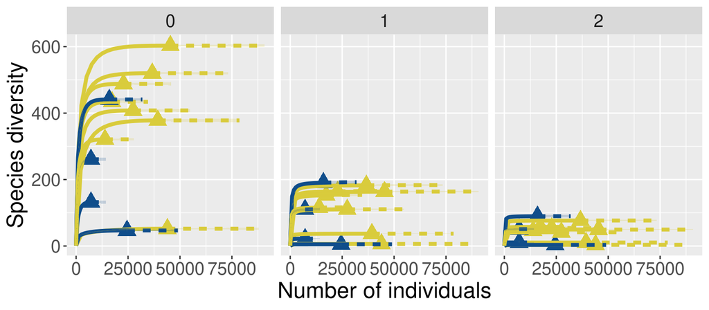

```r
# Plot rarefaction!
# rarefaction/extrapolation curve, type = 1

# Order q:
  # 0 = Richness/ Number of Total taxa
  # 1 = Exponential Shannon / Number of "Common" taxa
  # 2 = Inverse Simpson / Number of "Dominant" taxa

ggiNEXT(iNEXT_data, type = 1, facet.var = "Order.q") +
  facet_wrap(~Order.q, scales = "fixed") +
  scale_color_manual(values = iNEXT_color_df$gutsection_colors, guide = FALSE) +
  scale_fill_manual(values = iNEXT_color_df$gutsection_colors, guide = FALSE) +
  scale_shape_manual(values = base::rep(17, nsamples(raw_preprocessed_physeq)),
                     guide = FALSE) +
  theme(legend.position = "none")
```

My rarefaction curves and extrapolation looks like I would expect. Species diversity decreases as the hill numbers increase, which makes sense since the higher hill numbers represent taking into account more abundant samples. The range of species diversity is greater between my samples when I don’t take into account the abundance of my samples.